# Results Analysis IRT

# Analyses de modération à l’aide de modèles linéaires

## Résumé des résultats

Problème général : la plupart des données n’a pas une distribution normale + analyse de corrélation robuste sous matlab ne retourne aucun effet significatif, excepté pour WBSISuppression~AméliorationPSQI

Analyse réalisée avec des modèles linéaire (ie. équivalent anova)

### Variable “PTSD”

Seul effet de modération trouvé: le score de PCLS influe sur l’amélioration du score de IERS (mais non-indépendance de ces 2 mesures ??)

### Variable “sommeil”

Variable avec le plus d’effets de modération.

- L’amélioration de la qualité de sommeil (/10) est modérée par le score d’IERS-évitement et le score de PCLS.
- L’amélioration du score de PSQI est modéré par tout les scores de PTSD sauf IERS Intrusion, ainsi que par les score WBSI suppression et intrusion. Effet non sigbificatif mais tangent du score de ISI.
- L’amélioration du score de ISI est modéré par IERS neurovégétatif et score global (tangent pour IERS intrusion) ainsi que par le score de PSQI, dépression et WBSI suppression et intrusion.

```r
setwd('/home/claire/DATA/Etude Benjamin/')
```

```
The working directory was changed to /home/claire/DATA/Etude Benjamin inside a notebook chunk. The working directory will be reset when the chunk is finished running. Use the knitr root.dir option in the setup chunk to change the the working directory for notebook chunks.
```

```r
data48 <- read.csv('n48_PrePostSuivi.csv')
patient<-1:48
data48$patient<-as.factor(patient)
#-------------------
## Data Centering
#-------------------
# PTSD
data48$IERSIntrusionSouvenirs.PRE<-data48$IERSIntrusionSouvenirs.PRE-mean(data48$IERSIntrusionSouvenirs.PRE)
data48$IERSEvitement.PRE<-data48$IERSEvitement.PRE - mean(data48$IERSEvitement.PRE)
data48$IERSActivationNeurovégétative.PRE <-data48$IERSActivationNeurovégétative.PRE - mean(data48$IERSActivationNeurovégétative.PRE)
data48$IERS.Global.PRE<-data48$IERS.Global.PRE-mean(data48$IERS.Global.PRE)
data48$PCLS.PRE<-data48$PCLS.PRE-mean(data48$PCLS.PRE)
# Sommeil
data48$Epworth.PRE<-data48$Epworth.PRE-mean(data48$Epworth.PRE)
data48$ISI.PRE<-data48$ISI.PRE-mean(data48$ISI.PRE)
data48$PSQI.PRE<-data48$PSQI.PRE-mean(data48$PSQI.PRE)
data48$QualitéSommeilSur10.PRE<-data48$QualitéSommeilSur10.PRE-mean(data48$QualitéSommeilSur10.PRE)
# Imagerie mentale
data48$VVIQYeuxFermé.PRE<-data48$VVIQYeuxFermé.PRE-mean(data48$VVIQYeuxFermé.PRE)
data48$VVIQYeuxOuvert.PRE<-data48$VVIQYeuxOuvert.PRE-mean(data48$VVIQYeuxOuvert.PRE)
data48$GordonTotal.PRE <- data48$GordonTotal.PRE - mean(data48$GordonTotal.PRE)
data48$TestdeRotation.PRE <- data48$TestdeRotation.PRE - mean(data48$TestdeRotation.PRE)
# Cauchermars
data48$NombreCauchemarParMois.POST<-data48$NombreCauchemarParMois.POST-mean(data48$NombreCauchemarParMois.POST)
data48$NombreCauchemarParMois.PRE<-data48$NombreCauchemarParMois.PRE-mean(data48$NombreCauchemarParMois.PRE)
data48$Amelioration.NbCauchemars.PrePost <- data48$NombreCauchemarParMois.POST - data48$NombreCauchemarParMois.PRE
#-------------------------------------------------
# effet sur amaéliorations
#-------------------------------------------------
data48$AmeliorationSleep50<- data48$Sleep50.PRE-data48$Sleep50.POST
data48$AmeliorationDetresse<- data48$DétresseSur10.PRE-data48$DétresseSur10.POST
data48$AmeliorationIERS<- data48$IERS.Global.PRE-data48$IERS.Global.POST
data48$AmeliorationPCLS<- data48$PCLS.PRE-data48$PCLS.POST
data48$AmeliorationQualiteSommeil <- data48$QualitéSommeilSur10.POST-data48$QualitéSommeilSur10.PRE
data48$AmeliorationPSQI<-data48$PSQI.PRE-data48$PSQI.POST
data48$AmeliorationISI<- data48$ISI.PRE-data48$ISI.POST
data48$AmeliorationEpworth <-data48$Epworth.PRE-data48$Epworth.POST
data48$AmeliorationNuit <- data48$NuitCauchemarParMois.PRE-data48$NuitCauchemarParMois.POST
```

#### Modération par imagerie mentale

```r
xmdl<-lm(data48$AmeliorationNuit~data48$TestdeRotation.PRE)
summary(xmdl)
```

```
Call:
lm(formula = data48$AmeliorationNuit ~ data48$TestdeRotation.PRE)

Residuals:
    Min      1Q  Median      3Q     Max
-20.185  -5.468   0.581   6.281  16.082

Coefficients:
                          Estimate Std. Error t value Pr(>|t|)
(Intercept)                8.64063    1.22988   7.026 8.34e-09 ***
data48$TestdeRotation.PRE  0.06662    0.03118   2.137    0.038 *
---
Signif. codes:  0 ‘***’ 0.001 ‘**’ 0.01 ‘*’ 0.05 ‘.’ 0.1 ‘ ’ 1

Residual standard error: 8.521 on 46 degrees of freedom
Multiple R-squared:  0.0903,    Adjusted R-squared:  0.07052
F-statistic: 4.566 on 1 and 46 DF,  p-value: 0.03796
```

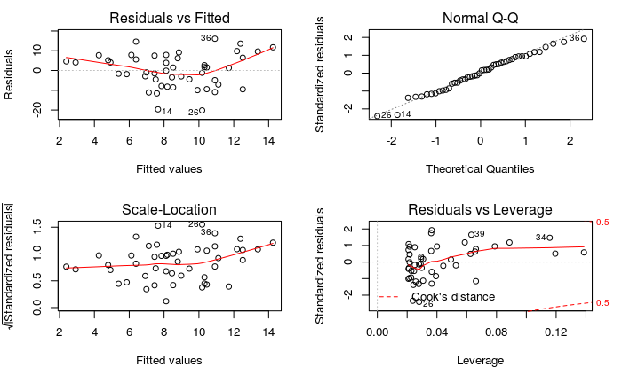

```r
par(mfrow = c(2,2))
plot(xmdl)
```

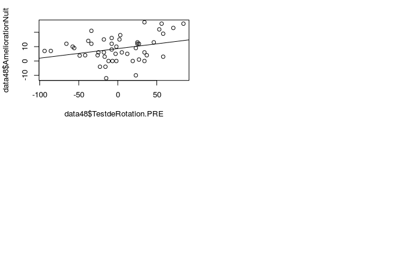

```r
plot(data48$TestdeRotation.PRE, data48$AmeliorationNuit)
abline(a=coef(xmdl)[1], coef(xmdl)[2])
```

```r
xmdl<-lm(data48$AmeliorationISI~data48$VVIQYeuxOuvert.PRE)
summary(xmdl)
```

```
Call:
lm(formula = data48$AmeliorationISI ~ data48$VVIQYeuxOuvert.PRE)

Residuals:
     Min       1Q   Median       3Q      Max
-22.1656  -3.2863  -0.9741   4.4362  13.0832

Coefficients:
                          Estimate Std. Error t value Pr(>|t|)
(Intercept)               -9.43750    0.87113  -10.83    3e-14 ***
data48$VVIQYeuxOuvert.PRE -0.12439    0.07726   -1.61    0.114
---
Signif. codes:  0 ‘***’ 0.001 ‘**’ 0.01 ‘*’ 0.05 ‘.’ 0.1 ‘ ’ 1

Residual standard error: 6.035 on 46 degrees of freedom
Multiple R-squared:  0.05334,   Adjusted R-squared:  0.03276
F-statistic: 2.592 on 1 and 46 DF,  p-value: 0.1142
```

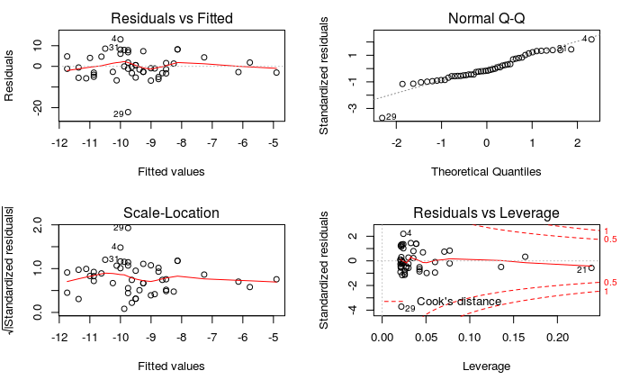

```r
par(mfrow = c(2,2))
plot(xmdl)
```

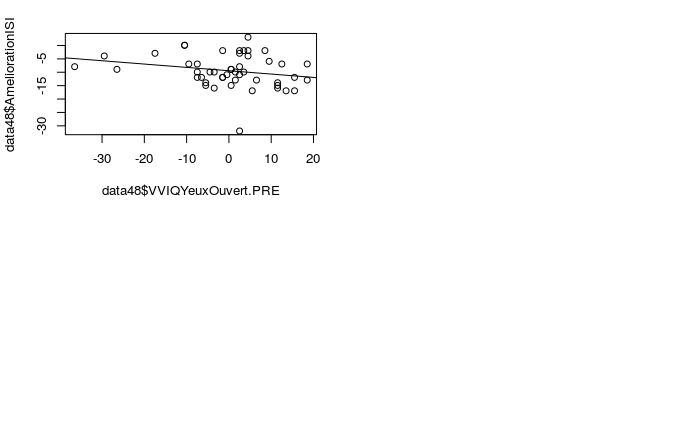

```r
plot(data48$VVIQYeuxOuvert.PRE, data48$AmeliorationISI)
abline(a=coef(xmdl)[1], coef(xmdl)[2])
```

## VD = cauchemars

### Amélioration du nombre de nombre de cauchemras par mois

Effet significatifs de 2 variables non supposées être modérateurs -> A voir avec analyse de médiation

- Effet du score de qualité de sommeil:

```r
xmdl<-lm(data48$Amelioration.NbCauchemars.PrePost~data48$QualitéSommeilSur10.PRE)
summary(xmdl)
```

```
Call:
lm(formula = data48$Amelioration.NbCauchemars.PrePost ~ data48$QualitéSommeilSur10.PRE)

Residuals:
    Min      1Q  Median      3Q     Max
-41.477  -6.694   4.903  10.094  46.762

Coefficients:
                                Estimate Std. Error t value Pr(>|t|)
(Intercept)                    1.087e-15  2.474e+00   0.000   1.0000
data48$QualitéSommeilSur10.PRE 4.239e+00  1.698e+00   2.497   0.0162 *
---
Signif. codes:  0 ‘***’ 0.001 ‘**’ 0.01 ‘*’ 0.05 ‘.’ 0.1 ‘ ’ 1

Residual standard error: 17.14 on 46 degrees of freedom
Multiple R-squared:  0.1193,    Adjusted R-squared:  0.1002
F-statistic: 6.234 on 1 and 46 DF,  p-value: 0.01618
```

- Effet du score de sentiment de controle spécifique:

```r
xmdl<-lm(data48$Amelioration.NbCauchemars.PrePost~data48$SentimentControleSpécifique.PRE)
summary(xmdl)
```

```
Call:
lm(formula = data48$Amelioration.NbCauchemars.PrePost ~ data48$SentimentControleSpécifique.PRE)

Residuals:
    Min      1Q  Median      3Q     Max
-39.915 -10.386   2.099  13.349  34.662

Coefficients:
                                       Estimate Std. Error t value Pr(>|t|)
(Intercept)                            -18.0578     7.5152  -2.403   0.0204 *
data48$SentimentControleSpécifique.PRE   1.4519     0.5707   2.544   0.0144 *
---
Signif. codes:  0 ‘***’ 0.001 ‘**’ 0.01 ‘*’ 0.05 ‘.’ 0.1 ‘ ’ 1

Residual standard error: 17.1 on 46 degrees of freedom
Multiple R-squared:  0.1233,    Adjusted R-squared:  0.1043
F-statistic: 6.472 on 1 and 46 DF,  p-value: 0.01438
```

### Nuit de cauchemars par mois

- effet Qualité de sommeil

```r
xmdl<-lm(data48$AmeliorationNuit~data48$QualitéSommeilSur10.PRE)
summary(xmdl)
```

```
Call:
lm(formula = data48$AmeliorationNuit ~ data48$QualitéSommeilSur10.PRE)

Residuals:
     Min       1Q   Median       3Q      Max
-23.5172  -4.5969  -0.3362   3.2206  17.7098

Coefficients:
                               Estimate Std. Error t value Pr(>|t|)
(Intercept)                      8.6406     1.1974   7.216 4.33e-09 ***
data48$QualitéSommeilSur10.PRE  -2.2270     0.8218  -2.710  0.00942 **
---
Signif. codes:  0 ‘***’ 0.001 ‘**’ 0.01 ‘*’ 0.05 ‘.’ 0.1 ‘ ’ 1

Residual standard error: 8.296 on 46 degrees of freedom
Multiple R-squared:  0.1377,    Adjusted R-squared:  0.1189
F-statistic: 7.344 on 1 and 46 DF,  p-value: 0.009422
```

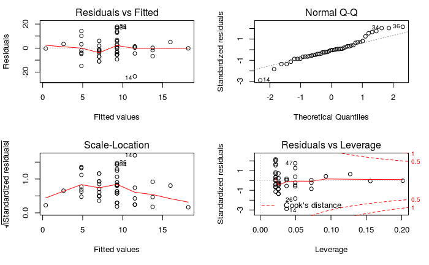

```r
par(mfrow = c(2,2))
plot(xmdl)
```

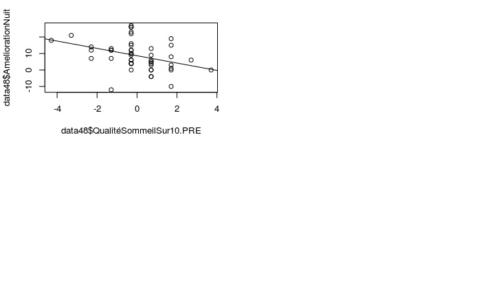

```r
plot(data48$QualitéSommeilSur10.PRE, data48$AmeliorationNuit)
abline(a=coef(xmdl)[1], coef(xmdl)[2])
```

!! Variance non hom

## VD = Amélioration PTSD

### IERS

- Effet score PCLS (mais non-indépendance des 2 mesures ??)

```r
xmdl<-lm(data48$AmeliorationIERS~data48$PCLS.PRE)
summary(xmdl)
```

```
Call:
lm(formula = data48$AmeliorationIERS ~ data48$PCLS.PRE)

Residuals:
    Min      1Q  Median      3Q     Max
-50.492  -7.046   1.052   3.295  41.084

Coefficients:
                Estimate Std. Error t value Pr(>|t|)
(Intercept)     -20.3750     2.1743  -9.371 3.08e-12 ***
data48$PCLS.PRE   0.2879     0.1279   2.251   0.0292 *
---
Signif. codes:  0 ‘***’ 0.001 ‘**’ 0.01 ‘*’ 0.05 ‘.’ 0.1 ‘ ’ 1

Residual standard error: 15.06 on 46 degrees of freedom
Multiple R-squared:  0.09923,   Adjusted R-squared:  0.07964
F-statistic: 5.067 on 1 and 46 DF,  p-value: 0.0292
```

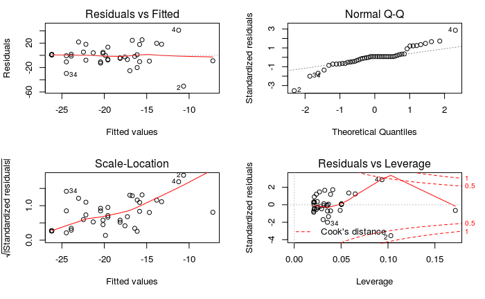

```r
par(mfrow = c(2,2))
plot(xmdl)
```

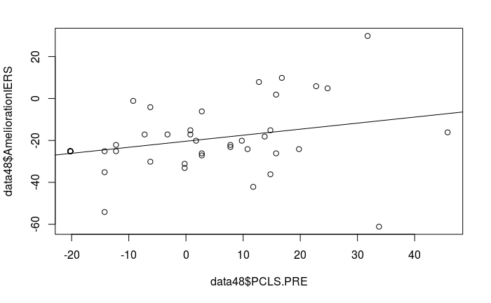

```r
plot(data48$PCLS.PRE, data48$AmeliorationIERS)
abline(a=coef(xmdl)[1], coef(xmdl)[2])
```

## VD = Evaluation Sommeil

### Qualité sommeil

- Effet score PCLS

```r
rm(xmdl)
xmdl<-lm(data48$AmeliorationQualiteSommeil~data48$PCLS.PRE)
summary(xmdl)
```

```
Call:
lm(formula = data48$AmeliorationQualiteSommeil ~ data48$PCLS.PRE)

Residuals:
   Min     1Q Median     3Q    Max
-3.514 -1.168  0.144  1.277  4.942

Coefficients:
                Estimate Std. Error t value Pr(>|t|)
(Intercept)      6.31250    0.26255  24.043   <2e-16 ***
data48$PCLS.PRE  0.03263    0.01544   2.113   0.0401 *
---
Signif. codes:  0 ‘***’ 0.001 ‘**’ 0.01 ‘*’ 0.05 ‘.’ 0.1 ‘ ’ 1

Residual standard error: 1.819 on 46 degrees of freedom
Multiple R-squared:  0.08847,   Adjusted R-squared:  0.06866
F-statistic: 4.465 on 1 and 46 DF,  p-value: 0.04006
```

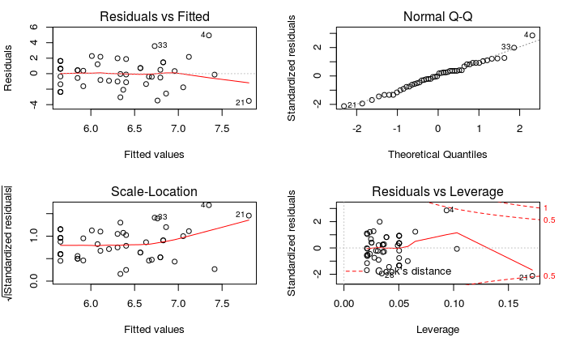

```r
par(mfrow = c(2,2))
plot(xmdl)
```

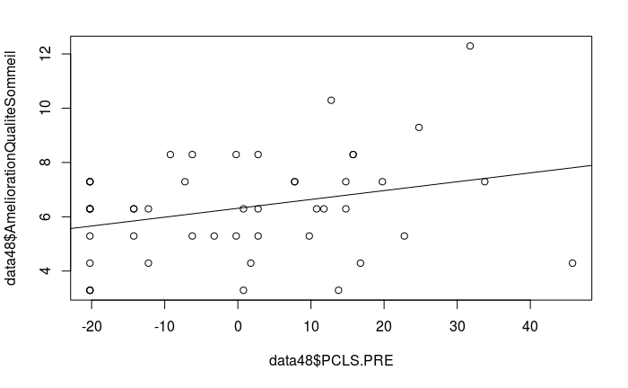

```r
plot(data48$PCLS.PRE, data48$AmeliorationQualiteSommeil)
abline(a=coef(xmdl)[1], coef(xmdl)[2])
```

- Effet score IERS evitement:

```r
rm(xmdl)
xmdl<-lm(data48$AmeliorationQualiteSommeil~data48$IERSEvitement.PRE)
summary(xmdl)
```

```
Call:
lm(formula = data48$AmeliorationQualiteSommeil ~ data48$IERSEvitement.PRE)

Residuals:
    Min      1Q  Median      3Q     Max
-3.1982 -1.1659  0.0116  1.3906  4.7700

Coefficients:
                         Estimate Std. Error t value Pr(>|t|)
(Intercept)               6.31250    0.26073  24.211   <2e-16 ***
data48$IERSEvitement.PRE  0.06449    0.02835   2.274   0.0277 *
---
Signif. codes:  0 ‘***’ 0.001 ‘**’ 0.01 ‘*’ 0.05 ‘.’ 0.1 ‘ ’ 1

Residual standard error: 1.806 on 46 degrees of freedom
Multiple R-squared:  0.1011,    Adjusted R-squared:  0.08154
F-statistic: 5.173 on 1 and 46 DF,  p-value: 0.02765
```

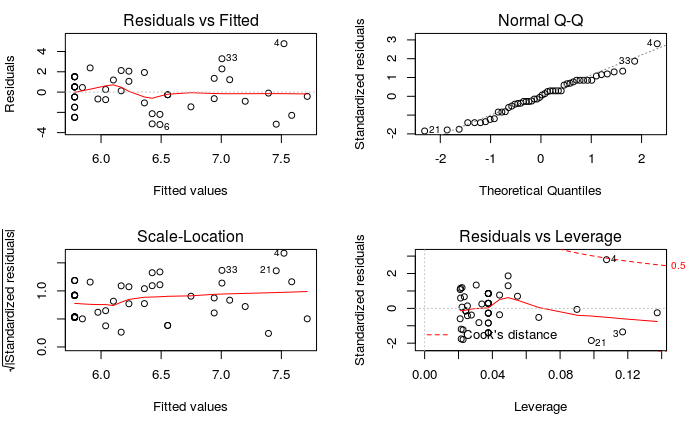

```r
par(mfrow = c(2,2))
plot(xmdl)
```

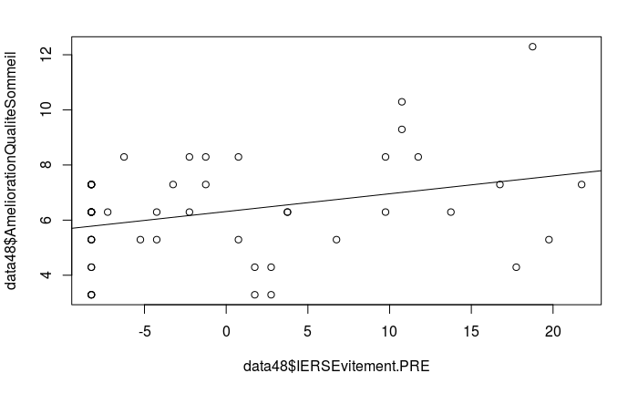

```r
plot(data48$IERSEvitement.PRE, data48$AmeliorationQualiteSommeil)
abline(a=coef(xmdl)[1], coef(xmdl)[2])
```

### PSQI

- effet score IERS:

```r
rm(xmdl)
xmdl<-lm(data48$AmeliorationPSQI~data48$IERS.Global.PRE)
summary(xmdl)
```

```
Call:
lm(formula = data48$AmeliorationPSQI ~ data48$IERS.Global.PRE)

Residuals:
    Min      1Q  Median      3Q     Max
-6.2036 -1.8400 -0.4304  1.9073  6.6727

Coefficients:
                       Estimate Std. Error t value Pr(>|t|)
(Intercept)            -6.60417    0.42450 -15.557   <2e-16 ***
data48$IERS.Global.PRE  0.04123    0.01773   2.326   0.0245 *
---
Signif. codes:  0 ‘***’ 0.001 ‘**’ 0.01 ‘*’ 0.05 ‘.’ 0.1 ‘ ’ 1

Residual standard error: 2.941 on 46 degrees of freedom
Multiple R-squared:  0.1052,    Adjusted R-squared:  0.08575
F-statistic: 5.408 on 1 and 46 DF,  p-value: 0.02451
```

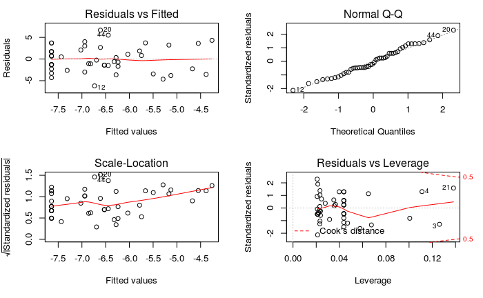

```r
par(mfrow = c(2,2))
plot(xmdl)
```

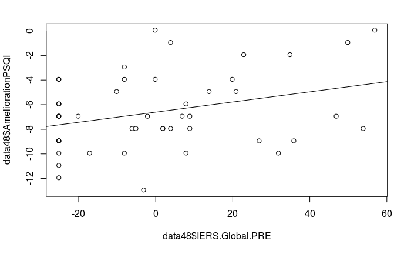

```r
plot(data48$IERS.Global.PRE, data48$AmeliorationPSQI )
abline(a=coef(xmdl)[1], coef(xmdl)[2])
```

```r
rm(xmdl)
xmdl<-lm(data48$AmeliorationPSQI~data48$IERSEvitement.PRE)
summary(xmdl)
```

```
Call:
lm(formula = data48$AmeliorationPSQI ~ data48$IERSEvitement.PRE)

Residuals:
    Min      1Q  Median      3Q     Max
-5.8454 -2.2888 -0.3787  1.9129  6.5806

Coefficients:
                         Estimate Std. Error t value Pr(>|t|)
(Intercept)              -6.60417    0.42090 -15.690   <2e-16 ***
data48$IERSEvitement.PRE  0.11481    0.04577   2.508   0.0157 *
---
Signif. codes:  0 ‘***’ 0.001 ‘**’ 0.01 ‘*’ 0.05 ‘.’ 0.1 ‘ ’ 1

Residual standard error: 2.916 on 46 degrees of freedom
Multiple R-squared:  0.1203,    Adjusted R-squared:  0.1012
F-statistic: 6.291 on 1 and 46 DF,  p-value: 0.01572
```

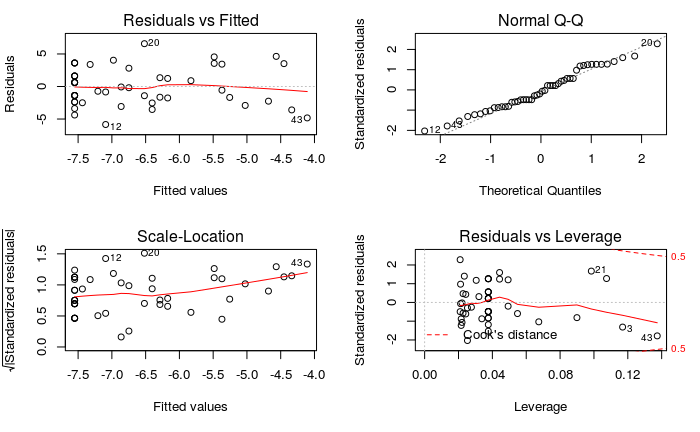

```r
par(mfrow = c(2,2))
plot(xmdl)
```

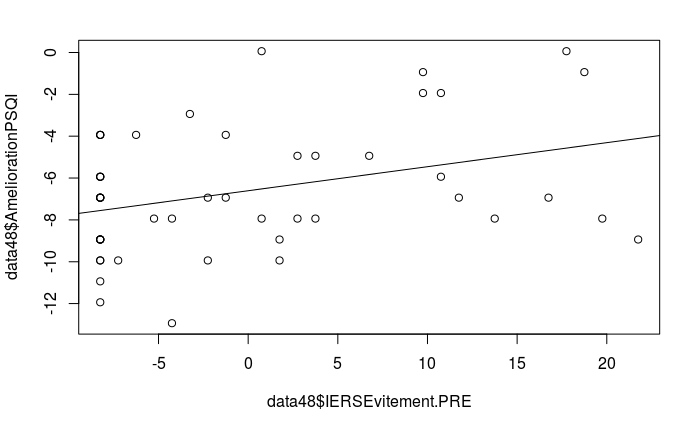

```r
plot(data48$IERSEvitement.PRE, data48$AmeliorationPSQI )
abline(a=coef(xmdl)[1], coef(xmdl)[2])
```

```r
rm(xmdl)
xmdl<-lm(data48$AmeliorationPSQI~data48$IERSActivationNeurovégétative.PRE)
summary(xmdl)
```

```
Call:
lm(formula = data48$AmeliorationPSQI ~ data48$IERSActivationNeurovégétative.PRE)

Residuals:
    Min      1Q  Median      3Q     Max
-6.8931 -1.5512  0.4253  1.6674  6.1069

Coefficients:
                                         Estimate Std. Error t value Pr(>|t|)
(Intercept)                              -6.60417    0.42938 -15.381   <2e-16 ***
data48$IERSActivationNeurovégétative.PRE  0.12556    0.06093   2.061    0.045 *
---
Signif. codes:  0 ‘***’ 0.001 ‘**’ 0.01 ‘*’ 0.05 ‘.’ 0.1 ‘ ’ 1

Residual standard error: 2.975 on 46 degrees of freedom
Multiple R-squared:  0.08452,   Adjusted R-squared:  0.06462
F-statistic: 4.247 on 1 and 46 DF,  p-value: 0.045
```

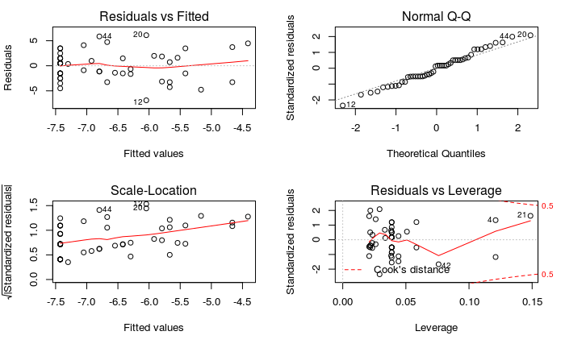

```r
par(mfrow = c(2,2))
plot(xmdl)
```

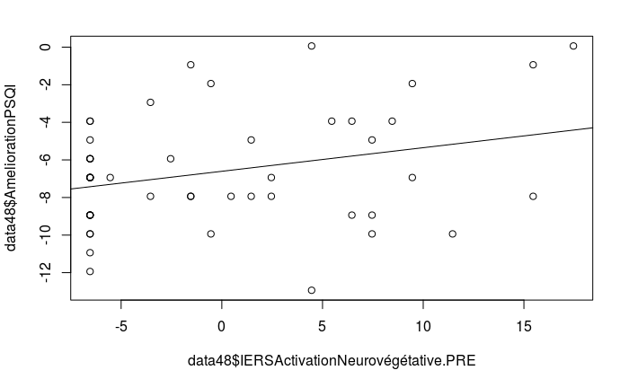

```r
plot(data48$IERSActivationNeurovégétative.PRE, data48$AmeliorationPSQI )
abline(a=coef(xmdl)[1], coef(xmdl)[2])
```

- Effet score PCLS:

```r
rm(xmdl)
xmdl<-lm(data48$AmeliorationPSQI~data48$PCLS.PRE)
summary(xmdl)
```

```
Call:
lm(formula = data48$AmeliorationPSQI ~ data48$PCLS.PRE)

Residuals:
    Min      1Q  Median      3Q     Max
-7.4397 -1.9174 -0.0783  1.8205  5.6838

Coefficients:
                Estimate Std. Error t value Pr(>|t|)
(Intercept)     -6.60417    0.40759 -16.203  < 2e-16 ***
data48$PCLS.PRE  0.07490    0.02397   3.124  0.00308 **
---
Signif. codes:  0 ‘***’ 0.001 ‘**’ 0.01 ‘*’ 0.05 ‘.’ 0.1 ‘ ’ 1

Residual standard error: 2.824 on 46 degrees of freedom
Multiple R-squared:  0.1751,    Adjusted R-squared:  0.1571
F-statistic: 9.762 on 1 and 46 DF,  p-value: 0.003082
```

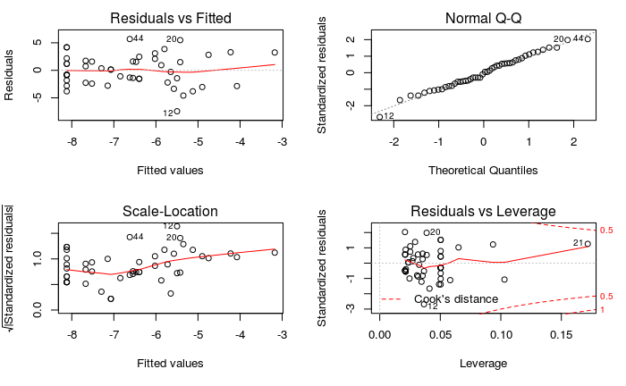

```r
par(mfrow = c(2,2))
plot(xmdl)
```

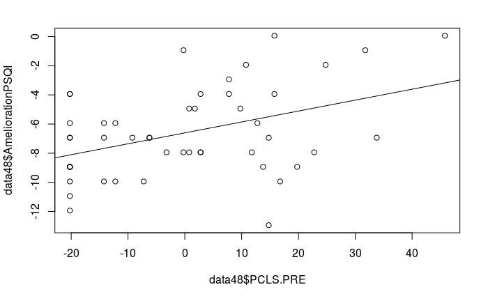

```r
plot(data48$PCLS.PRE, data48$AmeliorationPSQI )
abline(a=coef(xmdl)[1], coef(xmdl)[2])
```

- effet score ISI -p =0.05

```r
xmdl<-lm(data48$AmeliorationPSQI~data48$ISI.PRE)
summary(xmdl)
```

```
Call:
lm(formula = data48$AmeliorationPSQI ~ data48$ISI.PRE)

Residuals:
    Min      1Q  Median      3Q     Max
-6.3327 -1.8389 -0.3575  2.0719  6.3727

Coefficients:
               Estimate Std. Error t value Pr(>|t|)
(Intercept)    -6.60417    0.43117 -15.317   <2e-16 ***
data48$ISI.PRE  0.14108    0.07208   1.957   0.0564 .
---
Signif. codes:  0 ‘***’ 0.001 ‘**’ 0.01 ‘*’ 0.05 ‘.’ 0.1 ‘ ’ 1

Residual standard error: 2.987 on 46 degrees of freedom
Multiple R-squared:  0.07689,   Adjusted R-squared:  0.05682
F-statistic: 3.831 on 1 and 46 DF,  p-value: 0.05638
```

- effet WBSI suppression

```r
rm(xmdl)
xmdl<-lm(data48$AmeliorationPSQI~data48$WBSIsuppression.PRE)
summary(xmdl)
```

```
Call:
lm(formula = data48$AmeliorationPSQI ~ data48$WBSIsuppression.PRE)

Residuals:
    Min      1Q  Median      3Q     Max
-6.5589 -1.9203 -0.4083  2.0687  6.0917

Coefficients:
                            Estimate Std. Error t value Pr(>|t|)
(Intercept)                -11.96772    1.70290  -7.028 8.28e-09 ***
data48$WBSIsuppression.PRE   0.17466    0.05386   3.243  0.00221 **
---
Signif. codes:  0 ‘***’ 0.001 ‘**’ 0.01 ‘*’ 0.05 ‘.’ 0.1 ‘ ’ 1

Residual standard error: 2.805 on 46 degrees of freedom
Multiple R-squared:  0.1861,    Adjusted R-squared:  0.1684
F-statistic: 10.51 on 1 and 46 DF,  p-value: 0.002207
```

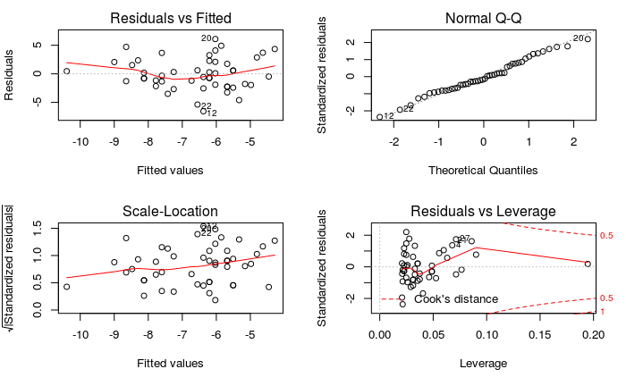

```r
par(mfrow = c(2,2))
plot(xmdl)
```

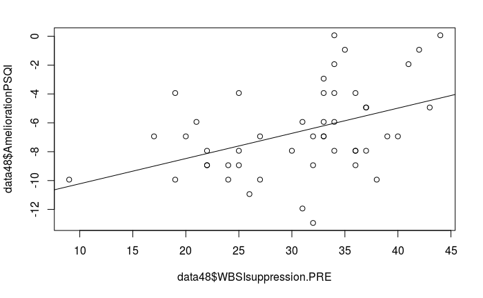

```r
plot(data48$WBSIsuppression.PRE, data48$AmeliorationPSQI )
abline(a=coef(xmdl)[1], coef(xmdl)[2])
```

- WBSI intrusion

```r
rm(xmdl)
xmdl<-lm(data48$AmeliorationPSQI~data48$WBSIintrusion.PRE)
summary(xmdl)
```

```
Call:
lm(formula = data48$AmeliorationPSQI ~ data48$WBSIintrusion.PRE)

Residuals:
    Min      1Q  Median      3Q     Max
-6.9794 -2.0481 -0.4686  1.7814  6.4977

Coefficients:
                          Estimate Std. Error t value Pr(>|t|)
(Intercept)              -10.09307    1.68609  -5.986 3.04e-07 ***
data48$WBSIintrusion.PRE   0.15904    0.07434   2.139   0.0378 *
---
Signif. codes:  0 ‘***’ 0.001 ‘**’ 0.01 ‘*’ 0.05 ‘.’ 0.1 ‘ ’ 1

Residual standard error: 2.965 on 46 degrees of freedom
Multiple R-squared:  0.09049,   Adjusted R-squared:  0.07072
F-statistic: 4.577 on 1 and 46 DF,  p-value: 0.03775
```

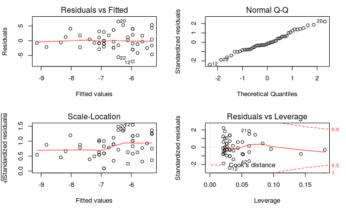

```r
par(mfrow = c(2,2))
plot(xmdl)
```

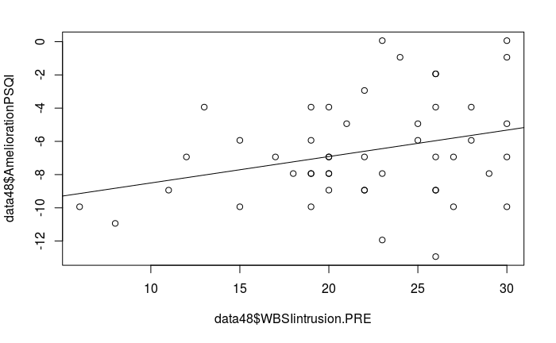

```r
plot(data48$WBSIintrusion.PRE, data48$AmeliorationPSQI )
abline(a=coef(xmdl)[1], coef(xmdl)[2])
```

### score ISI

- effet WBSI intrusion

```r
rm(xmdl)
xmdl<-lm(data48$AmeliorationISI~data48$WBSIintrusion.PRE)
summary(xmdl)
```

```
Call:
lm(formula = data48$AmeliorationISI ~ data48$WBSIintrusion.PRE)

Residuals:
    Min      1Q  Median      3Q     Max
-21.725  -3.727   0.523   3.552   9.496

Coefficients:
                         Estimate Std. Error t value Pr(>|t|)
(Intercept)              -17.9796     3.2782  -5.485  1.7e-06 ***
data48$WBSIintrusion.PRE   0.3894     0.1445   2.694  0.00982 **
---
Signif. codes:  0 ‘***’ 0.001 ‘**’ 0.01 ‘*’ 0.05 ‘.’ 0.1 ‘ ’ 1

Residual standard error: 5.765 on 46 degrees of freedom
Multiple R-squared:  0.1363,    Adjusted R-squared:  0.1175
F-statistic: 7.258 on 1 and 46 DF,  p-value: 0.009822
```

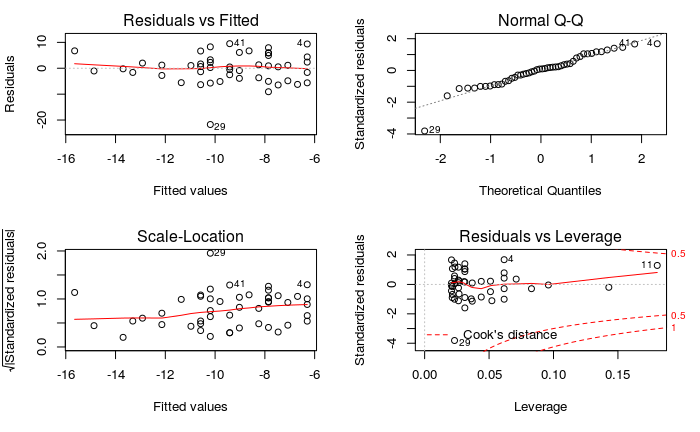

```r
par(mfrow = c(2,2))
plot(xmdl)
```

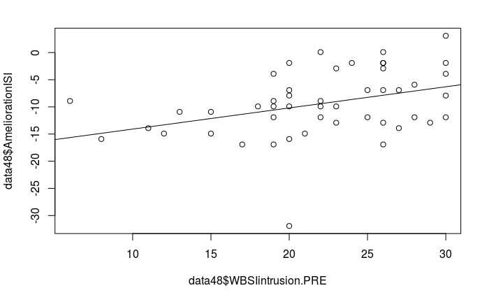

```r
plot(data48$WBSIintrusion.PRE, data48$AmeliorationISI)
abline(a=coef(xmdl)[1], coef(xmdl)[2])
```

- effet WBSI suppression

```r
rm(xmdl)
xmdl<-lm(data48$AmeliorationISI~data48$WBSIsuppression.PRE)
summary(xmdl)
```

```
Call:
lm(formula = data48$AmeliorationISI ~ data48$WBSIsuppression.PRE)

Residuals:
     Min       1Q   Median       3Q      Max
-19.3107  -3.3130  -0.0407   3.7088   8.6870

Coefficients:
                           Estimate Std. Error t value Pr(>|t|)
(Intercept)                -20.6105     3.3623  -6.130 1.85e-07 ***
data48$WBSIsuppression.PRE   0.3638     0.1064   3.421  0.00132 **
---
Signif. codes:  0 ‘***’ 0.001 ‘**’ 0.01 ‘*’ 0.05 ‘.’ 0.1 ‘ ’ 1

Residual standard error: 5.538 on 46 degrees of freedom
Multiple R-squared:  0.2028,    Adjusted R-squared:  0.1855
F-statistic:  11.7 on 1 and 46 DF,  p-value: 0.001318
```

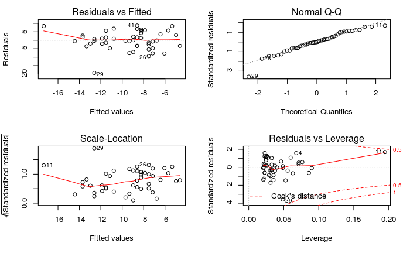

```r
par(mfrow = c(2,2))
plot(xmdl)
```

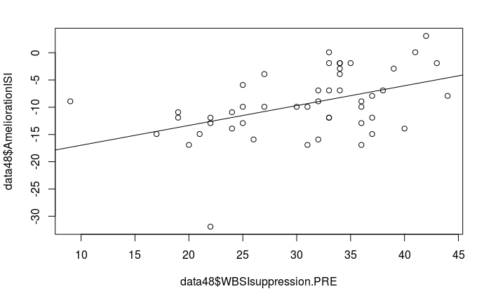

```r
plot(data48$WBSIsuppression.PRE, data48$AmeliorationISI)
abline(a=coef(xmdl)[1], coef(xmdl)[2])
```

- effet score dépression

```r
rm(xmdl)
xmdl<-lm(data48$AmeliorationISI~data48$dépression.PRE)
summary(xmdl)
```

```
Call:
lm(formula = data48$AmeliorationISI ~ data48$dépression.PRE)

Residuals:
     Min       1Q   Median       3Q      Max
-20.4225  -3.5215  -0.3809   4.4002   9.7853

Coefficients:
                      Estimate Std. Error t value Pr(>|t|)
(Intercept)           -11.4942     1.2807  -8.975 1.13e-11 ***
data48$dépression.PRE   0.4792     0.2225   2.154   0.0365 *
---
Signif. codes:  0 ‘***’ 0.001 ‘**’ 0.01 ‘*’ 0.05 ‘.’ 0.1 ‘ ’ 1

Residual standard error: 5.912 on 46 degrees of freedom
Multiple R-squared:  0.09159,   Adjusted R-squared:  0.07184
F-statistic: 4.638 on 1 and 46 DF,  p-value: 0.03655
```

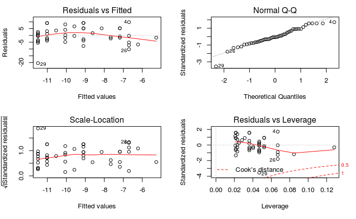

```r
par(mfrow = c(2,2))
plot(xmdl)
```

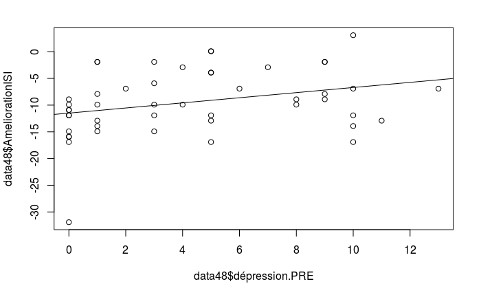

```r
plot(data48$dépression.PRE, data48$AmeliorationISI)
abline(a=coef(xmdl)[1], coef(xmdl)[2])
```

- effet score PSQI

```r
rm(xmdl)
xmdl<-lm(data48$AmeliorationISI~data48$PSQI.PRE)
summary(xmdl)
```

```
Call:
lm(formula = data48$AmeliorationISI ~ data48$PSQI.PRE)

Residuals:
     Min       1Q   Median       3Q      Max
-20.2538  -2.8447   0.3371   4.1250  10.9583

Coefficients:
                Estimate Std. Error t value Pr(>|t|)
(Intercept)      -9.4375     0.8082 -11.677 2.35e-15 ***
data48$PSQI.PRE   0.7576     0.2344   3.232  0.00227 **
---
Signif. codes:  0 ‘***’ 0.001 ‘**’ 0.01 ‘*’ 0.05 ‘.’ 0.1 ‘ ’ 1

Residual standard error: 5.6 on 46 degrees of freedom
Multiple R-squared:  0.1851,    Adjusted R-squared:  0.1674
F-statistic: 10.45 on 1 and 46 DF,  p-value: 0.002273
```

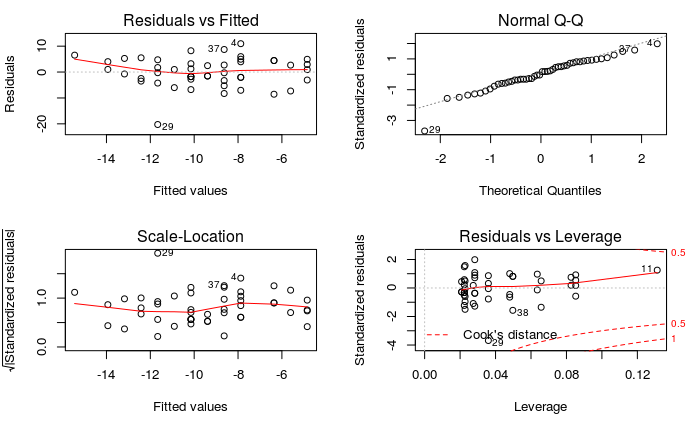

```r
par(mfrow = c(2,2))
plot(xmdl)
```

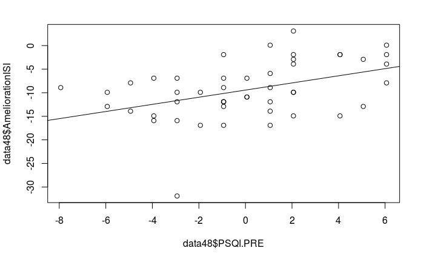

```r
plot(data48$PSQI.PRE, data48$AmeliorationISI)
abline(a=coef(xmdl)[1], coef(xmdl)[2])
```

- effet score PCLS

```r
rm(xmdl)
xmdl<-lm(data48$AmeliorationISI~data48$PCLS.PRE)
summary(xmdl)
```

```
Call:
lm(formula = data48$AmeliorationISI ~ data48$PCLS.PRE)

Residuals:
     Min       1Q   Median       3Q      Max
-19.6456  -3.6514   0.4031   4.3623   8.4323

Coefficients:
                Estimate Std. Error t value Pr(>|t|)
(Intercept)     -9.43750    0.82360 -11.459  4.5e-15 ***
data48$PCLS.PRE  0.14007    0.04844   2.892  0.00583 **
---
Signif. codes:  0 ‘***’ 0.001 ‘**’ 0.01 ‘*’ 0.05 ‘.’ 0.1 ‘ ’ 1

Residual standard error: 5.706 on 46 degrees of freedom
Multiple R-squared:  0.1538,    Adjusted R-squared:  0.1354
F-statistic: 8.362 on 1 and 46 DF,  p-value: 0.005832
```